# DATA624-HW1-TimeSeries

### 2.6e: `gasoline` - US finished motor gasoline product supplied: 2/2/1991-1/20/2017 (weekly).

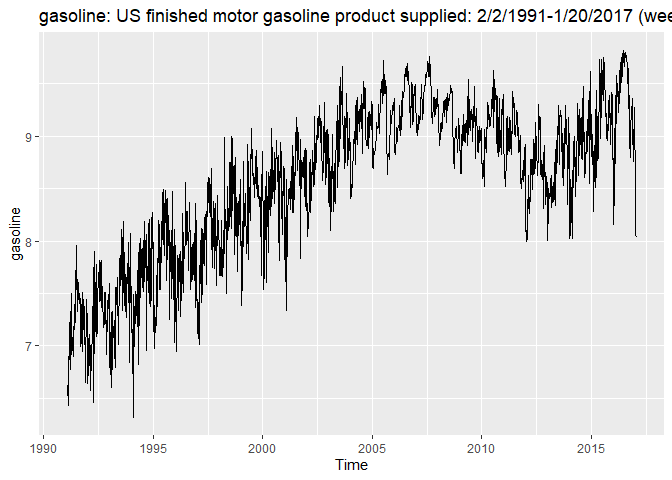

```r
mytitle <- "gasoline: US finished motor gasoline product supplied: 2/2/1991-1/20/2017 (weekly)"
autoplot(gasoline) + ggtitle(mytitle)
```

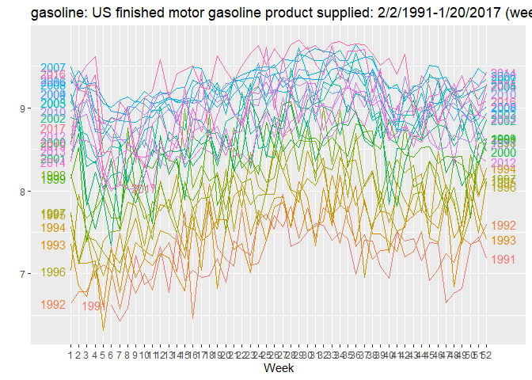

```r
ggseasonplot(gasoline, year.labels=TRUE, year.labels.left=TRUE) + ggtitle(mytitle)
```

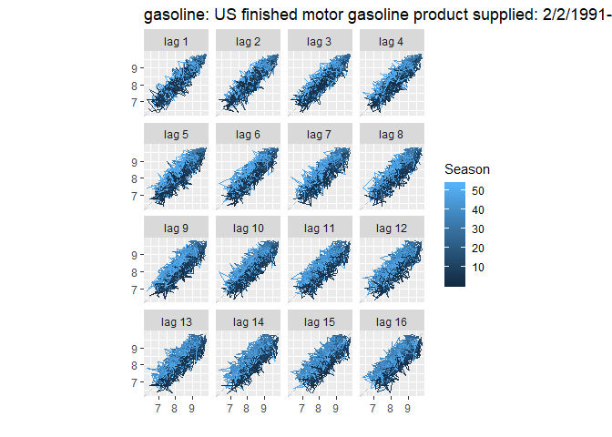

```r
## ggsubseriesplot(gasoline) + ggtitle(mytitle)
## Error in ggsubseriesplot(gasoline) : Each season requires at least 2 observations.
## This may be caused from specifying a time-series with non-integer frequency.

gglagplot(gasoline) + ggtitle(mytitle)
```

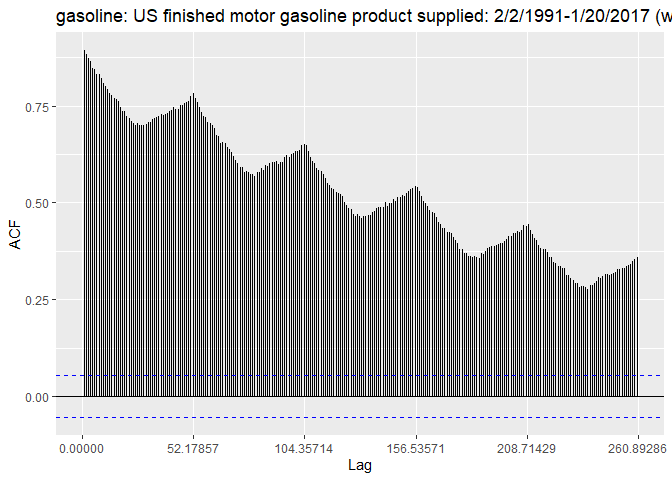

```r
ggAcf(gasoline, lag.max = 260) + ggtitle(mytitle)
```

##### The data exhibits an upward trend from 1991 up until 2007, when such increase stops.

##### Because of the way the weekly data is stored in the `ts` object, it appears that the software is unable to map the $n^{th}$ week of each calendar year, as it easily does with monthly or quarterly data.

##### The attribute associated with the `ts` object indicates that the frequency is 52.1785714 . If adjustments were made, it might be possible to have the software treat the frequency as 52 rather than 52.1785714 .

##### However, “scallops” in the ACF plot indicate seasonality on a 52-week cycle.